# Lab 3-1: Introduction to hypothesis tests

```
The 'mosaic' package masks several functions from core packages in order to add
additional features.  The original behavior of these functions should not be affected by this.
```

### Objectives:

For this lab you should…

- specify null and alternative hypotheses based on a question of interest, defining relevant parameters.
- recognize that hypothesis tests examine whether sample data provide sufficient evidence to refute the null and support the alternative.
- compare the strength of evidence that different samples have about the same hypothesis.

# Part 1: Get the data ready

Read the information about the dataset PASeniors in the Canvas quiz, then load the data here and remove incomplete observations using the cod chunk below.

```r
data(PASeniors)

PASeniors <- PASeniors |>
   na.omit()
```

# Part 2: Investigate research questions.

### A:

On average, do students spend more than 10 hours per week watching TV?

**TASK 2.A.1** Translate this research question into the correct set of hypotheses.

**Response**

**TASK 2.A.2** Generate an appropriate visualization to explore the data as they relate to your hypotheses. You will need to copy-paste this visualization into Canvas.

**Response**

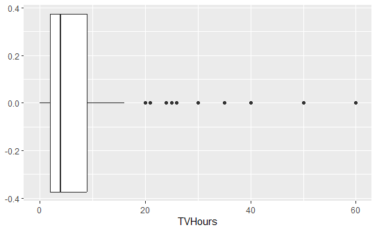

```r
gf_boxplot(~ TVHours, data = PASeniors)
```

**TASK 2.A.3** Calculate the relevant sample statistic from the data.

**Response**

```r
mean(~ TVHours, data=PASeniors)
```

```
[1] 6.783099
```

**TASK 2.A.4** Does your sample appear consistent with the alternative hypothesis?

A. Yes, this sample could be consistent with the alternative. B. No, this sample could not be consistent with the alternative

### B:

Do more than 20% of PA high school students take the bus to school?

**TASK 2.B.1** Translate this research question into the correct set of hypotheses.

**Response**

**TASK 2.B.2** Generate an appropriate visualization to explore the data as they relate to your hypotheses. You will need to copy-paste this visualization into Canvas.

**Response**

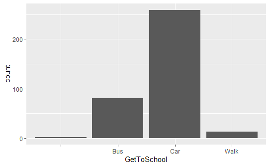

```r
gf_bar(~ GetToSchool, data= PASeniors)
```

```r
tally(~GetToSchool, data=PASeniors)
```

```
GetToSchool
      Bus  Car Walk
   2   81  259   13
```

**TASK 2.B.3** Calculate the relevant sample statistic from the data.

**Response**

**TASK 2.B.4** Does your sample appear consistent with the alternative hypothesis?

A. Yes, this sample could be consistent with the alternative. B. No, this sample could not be consistent with the alternative

### C:

Do vegetarians get more sleep on the weekends, compared to non-vegetarians?

**TASK 2.C.1** Translate this research question into the correct set of hypotheses.

**Response**

**TASK 2.C.2** Generate an appropriate visualization to explore the data as they relate to your hypotheses. You will need to copy-paste this visualization into Canvas.

**Response**

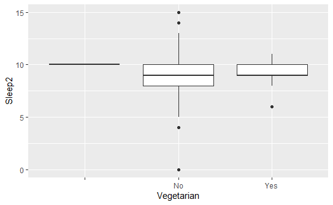

```r
gf_boxplot(Sleep2 ~ Vegetarian, data = PASeniors)
```

**TASK 2.C.3** Calculate the relevant sample statistic from the data.

**Response**

```r
favstats(Sleep2 ~ Vegetarian, data = PASeniors)
```

| Vegetarian | min | Q1 | median | Q3 | max | mean | sd | n | missing |
| --- | --- | --- | --- | --- | --- | --- | --- | --- | --- |
|  | 10 | 10 | 10 | 10 | 10 | 10.000000 | NA | 1 | 0 |
| No | 0 | 8 | 9 | 10 | 15 | 9.054315 | 1.576243 | 336 | 0 |
| Yes | 6 | 9 | 9 | 10 | 11 | 9.083333 | 1.114741 | 18 | 0 |

```r
9.054315-9.083333
```

```
[1] -0.029018
```

**TASK 2.C.4** Does your sample appear consistent with the alternative hypothesis?

A. Yes, this sample could be consistent with the alternative. B. No, this sample could not be consistent with the alternative

### D:

Research Question: Are vegetarians more likely to have allergies?

**TASK 2.D.1** Translate this research question into the correct set of hypotheses.

**Response**

**TASK 2.D.2** Generate an appropriate visualization to explore the data as they relate to your hypotheses. You will need to copy-paste this visualization into Canvas.

**Response**

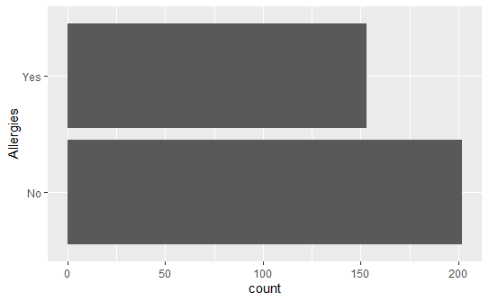

```r
gf_bar(Allergies~Vegetarian,data=PASeniors)
```

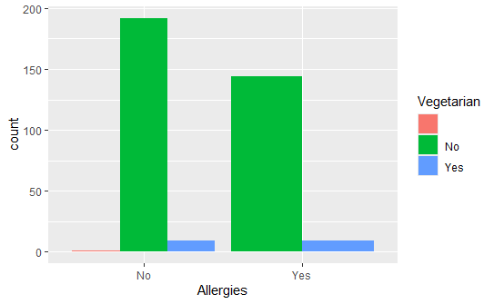

```r
gf_bar( ~ Allergies, fill = ~ Vegetarian, data = PASeniors, position = position_dodge())
```

**TASK 2.D.3** Calculate the relevant sample statistic from the data.

**Response**

```r
tally(Vegetarian~Allergies, data = PASeniors)
```

```
          Allergies
Vegetarian  No Yes
             1   0
       No  192 144
       Yes   9   9
```

**TASK 2.D.4** Does your sample appear consistent with the alternative hypothesis?

A. Yes, this sample could be consistent with the alternative. B. No, this sample could not be consistent with the alternative

### E:

Research Question: Is there a correlation between the number of hours that students spend hanging out with friends and the number of hours they spend doing homework?

**TASK 2.E.1** Translate this research question into the correct set of hypotheses.

**Response**

**TASK 2.E.2** Generate an appropriate visualization to explore the data as they relate to your hypotheses. You will need to copy-paste this visualization into Canvas.

**Response**

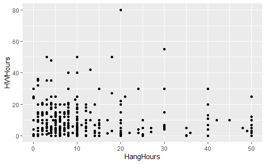

```r
gf_point(HWHours~HangHours, data=PASeniors)
```

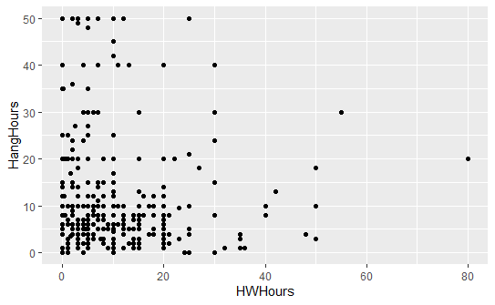

```r
gf_point(HangHours~HWHours, data=PASeniors)
```

**TASK 2.E.3** Calculate the relevant sample statistic from the data.

**Response**

```r
cor(HangHours~HWHours, data=PASeniors)
```

```
[1] -0.0694124
```

**TASK 2.E.4** Does your sample appear consistent with the alternative hypothesis?

A. Yes, this sample could be consistent with the alternative. B. No, this sample could not be consistent with the alternative

# Part 3: Translate more research questions.

For each of the following, simply translate the research questions into appropriate sets of hypotheses.

**TASK 3.1** Is the proportion of high school seniors that are female different from 50%?

**TASK 3.2** Do right-handed people have a different reaction time than left-handed people?

**TASK 3.3** Do people with allergies spend less time playing sports compared to people who don’t have allergies?

**TASK 3.4** Is the average number of texts sent in a day less than 100?

# Part 4:

The next three questions ask you to go the other direction: provided a parameter of interest, pose a research question that could be answered using these data. Be thorough and specific for full credit.

**TASK 4.1** Write a research question that can be answered by performing a hypothesis test for a population mean using the PASeniors dataset.

**TASK 4.2** Write a research question that can be answered by performing a hypothesis test for a difference in population proportions using the PASeniors dataset.

**TASK 4.3** Write a research question that can be answered by performing a hypothesis test for a difference in population means using the PASeniors dataset.